# Homework1

## Question 2: Combining data

```r
pm_2022 <- as.data.frame(pm_2022)
pm_2002 <- as.data.frame(pm_2002)
pm_merge <- merge(x=pm_2002, y=pm_2022, by="Site.ID", all.x=TRUE, all.y=TRUE)
dim(pm_merge)
```

```
[1] 4568832      43
```

```r
str(pm_merge)
```

```
'data.frame':   4568832 obs. of  43 variables:
 $ Site.ID                         : int  60010007 60010007 60010007 60010007 60010007 60010007 60010007 60010007 60010007 60010007 ...
 $ Date.x                          : chr  "05/08/2002" "05/08/2002" "05/08/2002" "05/08/2002" ...
 $ Source.x                        : chr  "AQS" "AQS" "AQS" "AQS" ...
 $ POC.x                           : int  1 1 1 1 1 1 1 1 1 1 ...
 $ Daily.Mean.PM2.5.Concentration.x: num  9.6 9.6 9.6 9.6 9.6 9.6 9.6 9.6 9.6 9.6 ...
 $ Units.x                         : chr  "ug/m3 LC" "ug/m3 LC" "ug/m3 LC" "ug/m3 LC" ...
 $ Daily.AQI.Value.x               : int  52 52 52 52 52 52 52 52 52 52 ...
 $ Local.Site.Name.x               : chr  "Livermore" "Livermore" "Livermore" "Livermore" ...
 $ Daily.Obs.Count.x               : int  1 1 1 1 1 1 1 1 1 1 ...
 $ Percent.Complete.x              : num  100 100 100 100 100 100 100 100 100 100 ...
 $ AQS.Parameter.Code.x            : int  88101 88101 88101 88101 88101 88101 88101 88101 88101 88101 ...
 $ AQS.Parameter.Description.x     : chr  "PM2.5 - Local Conditions" "PM2.5 - Local Conditions" "PM2.5 - Local Conditions" "PM2.5 - Local Conditions" ...
 $ Method.Code.x                   : int  120 120 120 120 120 120 120 120 120 120 ...
 $ Method.Description.x            : chr  "Andersen RAAS2.5-300 PM2.5 SEQ w/WINS" "Andersen RAAS2.5-300 PM2.5 SEQ w/WINS" "Andersen RAAS2.5-300 PM2.5 SEQ w/WINS" "Andersen RAAS2.5-300 PM2.5 SEQ w/WINS" ...
```

[output cut: 29 more lines]

```r
head(pm_merge[, c("Date.x","Local.Site.Name.x","CBSA.Name.x","Daily.Mean.PM2.5.Concentration.x","Daily.AQI.Value.x", "Site.Latitude.x", "Site.Longitude.x", "Date.y","Local.Site.Name.y","CBSA.Name.y","Daily.Mean.PM2.5.Concentration.y","Daily.AQI.Value.y", "Site.Latitude.y", "Site.Longitude.y")], n = 5)
```

```
      Date.x Local.Site.Name.x                       CBSA.Name.x
1 05/08/2002         Livermore San Francisco-Oakland-Hayward, CA
2 05/08/2002         Livermore San Francisco-Oakland-Hayward, CA
3 05/08/2002         Livermore San Francisco-Oakland-Hayward, CA
4 05/08/2002         Livermore San Francisco-Oakland-Hayward, CA
5 05/08/2002         Livermore San Francisco-Oakland-Hayward, CA
  Daily.Mean.PM2.5.Concentration.x Daily.AQI.Value.x Site.Latitude.x
1                              9.6                52        37.68753
2                              9.6                52        37.68753
3                              9.6                52        37.68753
4                              9.6                52        37.68753
5                              9.6                52        37.68753
  Site.Longitude.x     Date.y Local.Site.Name.y
1        -121.7842 12/06/2022         Livermore
2        -121.7842 06/02/2022         Livermore
3        -121.7842 10/27/2022         Livermore
4        -121.7842 08/18/2022         Livermore
5        -121.7842 07/09/2022         Livermore
                        CBSA.Name.y Daily.Mean.PM2.5.Concentration.y
1 San Francisco-Oakland-Hayward, CA                              4.6
2 San Francisco-Oakland-Hayward, CA                              5.2
3 San Francisco-Oakland-Hayward, CA                              5.2
4 San Francisco-Oakland-Hayward, CA                             10.5
5 San Francisco-Oakland-Hayward, CA                              4.0
  Daily.AQI.Value.y Site.Latitude.y Site.Longitude.y
1                26        37.68753        -121.7842
2                29        37.68753        -121.7842
3                29        37.68753        -121.7842
4                54        37.68753        -121.7842
5                22        37.68753        -121.7842
```

```r
library(stringi)
pm_merge$year.x <- as.integer(stri_sub(pm_merge$Date.x, -4, -1))
pm_merge$year.y <- as.integer(stri_sub(pm_merge$Date.y, -4, -1))
head(pm_merge)
```

```
   Site.ID     Date.x Source.x POC.x Daily.Mean.PM2.5.Concentration.x  Units.x
1 60010007 05/08/2002      AQS     1                              9.6 ug/m3 LC
2 60010007 05/08/2002      AQS     1                              9.6 ug/m3 LC
3 60010007 05/08/2002      AQS     1                              9.6 ug/m3 LC
4 60010007 05/08/2002      AQS     1                              9.6 ug/m3 LC
5 60010007 05/08/2002      AQS     1                              9.6 ug/m3 LC
6 60010007 05/08/2002      AQS     1                              9.6 ug/m3 LC
  Daily.AQI.Value.x Local.Site.Name.x Daily.Obs.Count.x Percent.Complete.x
1                52         Livermore                 1                100
2                52         Livermore                 1                100
3                52         Livermore                 1                100
4                52         Livermore                 1                100
5                52         Livermore                 1                100
6                52         Livermore                 1                100
  AQS.Parameter.Code.x AQS.Parameter.Description.x Method.Code.x
```

[output cut: 69 more lines]

```r
library(dplyr)
pm_merge <- pm_merge %>%
  rename(
    Date_2002 = Date.x,
    Date_2022 = Date.y,
    Daily.Mean.Pm2.5_2002 = Daily.Mean.PM2.5.Concentration.x,
    Daily.Mean.Pm2.5_2022 = Daily.Mean.PM2.5.Concentration.y,
    Daily.AQI.Value_2002 = Daily.AQI.Value.x,
    Daily.AQI.Value_2022 = Daily.AQI.Value.y,
    year2002 = year.x,
    year2022 = year.y)

names(pm_merge)
```

```
 [1] "Site.ID"                     "Date_2002"
 [3] "Source.x"                    "POC.x"
 [5] "Daily.Mean.Pm2.5_2002"       "Units.x"
 [7] "Daily.AQI.Value_2002"        "Local.Site.Name.x"
 [9] "Daily.Obs.Count.x"           "Percent.Complete.x"
[11] "AQS.Parameter.Code.x"        "AQS.Parameter.Description.x"
[13] "Method.Code.x"               "Method.Description.x"
[15] "CBSA.Code.x"                 "CBSA.Name.x"
[17] "State.FIPS.Code.x"           "State.x"
[19] "County.FIPS.Code.x"          "County.x"
[21] "Site.Latitude.x"             "Site.Longitude.x"
[23] "Date_2022"                   "Source.y"
[25] "POC.y"                       "Daily.Mean.Pm2.5_2022"
[27] "Units.y"                     "Daily.AQI.Value_2022"
[29] "Local.Site.Name.y"           "Daily.Obs.Count.y"
[31] "Percent.Complete.y"          "AQS.Parameter.Code.y"
[33] "AQS.Parameter.Description.y" "Method.Code.y"
[35] "Method.Description.y"        "CBSA.Code.y"
[37] "CBSA.Name.y"                 "State.FIPS.Code.y"
[39] "State.y"                     "County.FIPS.Code.y"
[41] "County.y"                    "Site.Latitude.y"
[43] "Site.Longitude.y"            "year2002"
[45] "year2022"
```

## Question 3: Create basic map (leaflet)

```r
library(leaflet)
map_data <- pm_merge %>%
  filter(!is.na(Site.Latitude.x) & !is.na(Site.Longitude.x) &
         !is.na(Site.Latitude.y) & !is.na(Site.Longitude.y))
map_data <- pm_merge[!duplicated(pm_merge[, c("Site.Longitude.x", "Site.Latitude.x")]), ]

leaflet() %>%
  addTiles() %>%


  addCircleMarkers(
    data = map_data,
    lng = ~Site.Longitude.x, lat = ~Site.Latitude.x,
    color = "red", radius = 4, stroke = FALSE, fillOpacity = 0.6,
    label = "2002 Site"
  ) %>%


  addCircleMarkers(
    data = map_data,
    lng = ~Site.Longitude.y, lat = ~Site.Latitude.y,
    color = "blue", radius = 4, stroke = FALSE, fillOpacity = 0.6,
    label = "2022 Site"
  ) %>%

  addLegend(
    position = "bottomright",
    colors = c("red", "blue"),
    labels = c("2002 Monitoring Sites", "2022 Monitoring Sites"),
    title = "Monitoring Year"
  )
```

[interactive chart not shown]

## California State PM2.5 Concentration 2002 vs 2022

```r
library(ggplot2)
library(tidyr)
#checked all state variables mention California
state_data <- pm_merge %>% select(Site.ID,Daily.Mean.Pm2.5_2002, Daily.Mean.Pm2.5_2022) %>%
    drop_na(Daily.Mean.Pm2.5_2002, Daily.Mean.Pm2.5_2022) %>%
  pivot_longer(cols=c(Daily.Mean.Pm2.5_2002, Daily.Mean.Pm2.5_2022), names_to="Year", values_to="PM2.5") %>%
  #switching format of data to stack year 2002 and 2022 into rows that can be subtracted
  mutate(Year = ifelse(Year == "Daily.Mean.Pm2.5_2002", "2002", "2022"))


state_pm_summary <- state_data %>%
  group_by(Year)%>%
  summarize(
    Min_PM2.5=min(PM2.5),
    Mean_PM2.5 = mean(PM2.5),
    Median_PM2.5 = median(PM2.5),
    Max_PM2.5 = max(PM2.5)
  )
print(state_pm_summary)
```

```
# A tibble: 2 × 5
  Year  Min_PM2.5 Mean_PM2.5 Median_PM2.5 Max_PM2.5
  <chr>     <dbl>      <dbl>        <dbl>     <dbl>
1 2002          1       19.0         14.1      104.
2 2022          1       10.4          8.6      218.
```

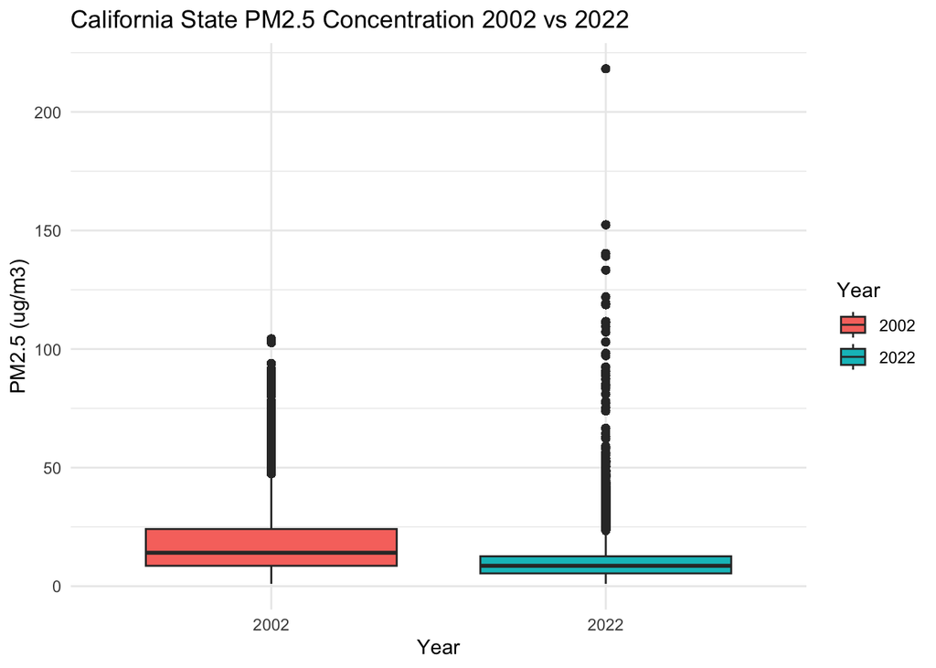

```r
ggplot(state_data, aes(x = Year, y = PM2.5, fill = Year)) +
  geom_boxplot() +
  theme_minimal() +
  labs(title = "California State PM2.5 Concentration 2002 vs 2022", x = "Year", y = "PM2.5 (ug/m3)")
```

At the California state level, the boxplots show that 50% of the data and IQR is much smaller and lower in 2022 compared to 2002, however there are large outliers influencing the distribution in the 2022 boxplot. The highest daily average PM2.5 value is 218 in the 2022 group, whereas in the 2002 group it is 104. Interestingly, the average of daily average PM2.5 values are much higher in the 2002 group with a value of 19.0, and the median of the daily average PM2.5 value is also 14.1. Since the highest value is now 218 in the 2022 group, this means some rows were removed for missing data in either dataset: 2002 or 2022 (maybe site was newly placed or removed over the 20 years).

```r
library(ggplot2)
library(trelliscopejs)
county_data <- pm_merge %>% filter(County.x == County.y) %>%
  select(County=County.y, Daily.Mean.Pm2.5_2002, Daily.Mean.Pm2.5_2022) %>%
  drop_na(Daily.Mean.Pm2.5_2002, Daily.Mean.Pm2.5_2022) %>%
  pivot_longer(cols=c(Daily.Mean.Pm2.5_2002, Daily.Mean.Pm2.5_2022), names_to="Year", values_to="PM2.5") %>%
  #switching format of data to stack year 2002 and 2022 into rows that can be subtracted
  mutate(Year = ifelse(Year == "Daily.Mean.Pm2.5_2002", "2002", "2022"))

county_pm_summary <- county_data %>%
  group_by(County, Year) %>%
  summarize(
    Min_PM2.5    = min(PM2.5),
    Mean_PM2.5   = mean(PM2.5),
    Median_PM2.5 = median(PM2.5),
    Max_PM2.5    = max(PM2.5),
    Total_Sites  = n(),
    .groups = "drop_last"
  )
print(county_pm_summary)
```

```
# A tibble: 82 × 7
# Groups:   County [41]
   County       Year  Min_PM2.5 Mean_PM2.5 Median_PM2.5 Max_PM2.5 Total_Sites
   <chr>        <chr>     <dbl>      <dbl>        <dbl>     <dbl>       <int>
 1 Alameda      2002        1.9      14.8          9.85      61.6       32832
 2 Alameda      2022        1.3       7.59         6.35      25.9       32832
 3 Butte        2002        1.5      14.7         11.7       63.7      114019
 4 Butte        2022        1         6.95         5         36.6      114019
 5 Calaveras    2002        2         9.9          8         40         21180
 6 Calaveras    2022        1         6.07         5         25.9       21180
 7 Colusa       2002        1        11.7          9         57         33915
 8 Colusa       2022        1.1       7.28         6.1       37         33915
 9 Contra Costa 2002        2        15.1          9.5       76.7      127236
10 Contra Costa 2022        1.2       7.01         5.9       32.7      127236
# ℹ 72 more rows
```

```r
ggplot(county_data, aes(x = Year, y = PM2.5, fill = Year)) +
  geom_boxplot(outlier.size = 0.5, alpha = 0.8) +
  theme_minimal(base_size = 8) +
  labs( title = "County Level PM2.5 Concentration 2002 vs 2022",
    x = "Year",
    y = "PM2.5 Concentration (ug/m3)"
  ) +
facet_trelliscope(
    ~County,
    nrow = 1,
    ncol = 3,
    as_plotly = FALSE,
    path = "trelliscope"
  )
```

```
using data from the first layer
```

[interactive chart not shown]

Disclaimer: I had to search up this package in order to print many boxplots for 70+ counties in California. The smallest distributions of daily average PM 2.5 concentrations was found in Trinity County in 2002 and 2022,nearly 1 ug/m3. Riverside had the highest distribution of daily average PM 2.5 concentrations in 2002 with Kern coming in second. Overall, all counties seem to have higher distributions in 2002 then 2022.

```r
losangeles <- pm_merge %>% filter(County.x == "Los Angeles" & County.y == "Los Angeles") %>%
  select(Daily.Mean.Pm2.5_2002, Daily.Mean.Pm2.5_2022) %>%
  drop_na(Daily.Mean.Pm2.5_2002, Daily.Mean.Pm2.5_2022) %>%
  pivot_longer(cols=c(Daily.Mean.Pm2.5_2002, Daily.Mean.Pm2.5_2022), names_to="Year", values_to="PM2.5") %>%
  #switching format of data to stack year 2002 and 2022 into rows that can be subtracted
  mutate(Year = ifelse(Year == "Daily.Mean.Pm2.5_2002", "2002", "2022"))

losangeles_pm_summary <- losangeles %>%
  group_by(Year)%>%
  summarize(
    Min_PM2.5=min(PM2.5),
    Mean_PM2.5 = mean(PM2.5),
    Median_PM2.5 = median(PM2.5),
    Max_PM2.5 = max(PM2.5)
  )
print(losangeles_pm_summary)
```

```
# A tibble: 2 × 5
  Year  Min_PM2.5 Mean_PM2.5 Median_PM2.5 Max_PM2.5
  <chr>     <dbl>      <dbl>        <dbl>     <dbl>
1 2002          1       20.4         18        72.4
2 2022          1       10.9         10.1      38
```

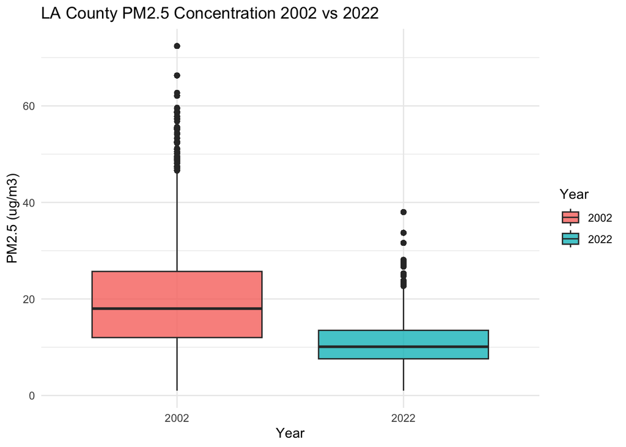

```r
ggplot(losangeles, aes(x = Year, y = PM2.5, fill = Year)) +
  geom_boxplot(alpha = 0.8) +
  theme_minimal() +
  labs(title = "LA County PM2.5 Concentration 2002 vs 2022", x = "Year", y = "PM2.5 (ug/m3)")
```

Similar to what we’ve seen in the county level visualizations, Los Angeles County has a higher distribution in 2002 compared to 2022 with many outliers pulling the whisker end of the plot. A possibility of this observation is that there the air quality was bad due to the 2002 wildfires, according to external sources.